# Was macht ein Teilchenphysiker?

Lattice QCD – Quarks auf dem Gitter

Gianluca · Doktorand · Theoretische Teilchenphysik

2026-04-17

## Warum Teilchenphysik?

- Woraus besteht die Welt wirklich?
- Warum haben Teilchen Masse?
- Was hält Protonen & Neutronen zusammen?
- Lassen sich mathematische Formeln zur Beschreibung der Natur finden?

[figure not shown]

https://particle.univie.ac.at/

## Das Standardmodell (Überblick)

[figure not shown]

Von MissMJ & Cush / abgeleitetes Werk: Polluks - Standard Model of Elementary Particles.svg, Gemeinfrei, https://commons.wikimedia.org/w/index.php?curid=11307906

## Die starke Wechselwirkung

- Beschrieben durch: **QCD** (Quantenchromodynamik)
- Quarks tragen *Farbladung*
- Vermittelt durch Gluonen
- Verantwortlich für ~99% der Masse sichtbarer Materie

[figure not shown]

By Arpad Horvath - Own work, CC BY-SA 2.5, https://commons.wikimedia.org/w/index.php?curid=637353

## Das Problem

QCD-Gleichungen sind bekannt …

**… aber extrem schwer zu lösen!**

Warum?

## Klassische Physik vs. Quantenphysik

- **Klassische Physik:** Natur wählt den Pfad mit minimaler *Wirkung*

Die *Wirkung* ist eine Zahl, die angibt, wie sehr sich das Universum “anstrengen muss” um einen Pfad durchzuführen (Analogon: Effizienz)

## Klassische Physik vs. Quantenphysik

- **Klassische Physik:** Natur wählt den Pfad mit minimaler Wirkung
- **Quantenphysik:** Alle Pfade tragen bei, aber kleine Wirkung → größere Bedeutung

Aufsummierung und Mittelung aller Pfade wird als *Pfadintegral* bezeichnet

## Pfadintegral in der QED

Beispiel: **Elektron–Elektron-Streuung** (Elektronen werden aufeinander geschossen) Ziel: Berechne die Wahrscheinlichkeit, dass das Elektron in einem bestimmten Winkel gestreut wird und vergleiche mit Experiment

## Pfadintegral in der QED

Beispiel: **Elektron–Elektron-Streuung** (Elektronen werden aufeinander geschossen) Ziel: Berechne die Wahrscheinlichkeit, dass das Elektron in einem bestimmten Winkel gestreut wird und vergleiche mit Experiment

Ein Diagramm = ein Term im Pfadintegral (Feynman-Diagramme)

## Pfadintegral in der QED

Beispiel: **Elektron–Elektron-Streuung**

**Speziell in der QED**: Je mehr Wechselwirkungen, desto unwichtiger werden Pfade (ist nicht immer so)

## Pfadintegral in der QED

Beispiel: **Elektron–Elektron-Streuung**

[figure not shown]

→ Um Observablen zu berechnen und mit Experimenten vergleichen zu können braucht man nur eine **endliche** Anzahl an Diagrammen

## Wichtige Klarstellung

- Feynman-Diagramme sind **keine echten Teilchenbahnen**
- Sie sind ein mathematischer Trick
- Hilfreich, um das Pfadintegral übersichtlich zu berechnen
- Bewart uns fürs erste davor, tiefer in die *Quantenfeldtheorie* gehen zu müssen

## Und jetzt: QCD

- Starke Kopplung: Komplizierte Diagramme werden **nicht** unwichtig
- Unendlich viele wichtige Diagramme

**→ Keine andere Wahl mehr, als mit Feldern zu rechnen!**

## Rechnen in der Quantenfeldtheorie (QFT)

- Teilchen sind Anregungen verschiedener Quantenfelder
- Für Rechnungen muss die Raumzeit diskretisiert werden
- Hochdimensionale Integrale (meist mindestens $10^6$ Variablen)
- Kann nicht analytisch berechnet werden → Wir müssen Computer verwenden!
- QCD auf dem Computer: *Lattice QCD*

[figure not shown]

## Die Idee von Lattice QCD

- Beschränke das Universum auf ein **sehr kleines Volumen** (kleiner als ein Atom)
- Raum und Zeit werden zum *Gitter* (eng.: *Lattice*)
- Quarks sitzen auf Gitterpunkten
- Gluonen auf den Verbindungen
- Genaue Größe des Gitters wird vor der Simulation festgelegt
- Echte Physik bekommt man nur im Fall *$a \rightarrow 0$*

[figure not shown]

## Lattice QCD

**Wie rechnet man jetzt auf dem Gitter?**

- Ähnlich zum Pfadintegral brauchen wir jetzt die wichtigen **Feldkonfigurationen**
- Aber wie gesagt, gibt es in der QCD unendlich viele

**Brauchen wir denn wirklich alle?**

## Lattice QCD

- Vergleich mit etwas bekanntem: **Umfragen**
- In Umfragen wird nur ein kleiner *representativer Teil* der Bevölkerung befragt
- Das Ergebnis hat dann eine gewisse Unsicherheit, diese ist aber proportional zu $1 / \sqrt{N_\textrm{Befragte}}$
- Genau so simulieren wir also auch nur einen representativen Teil der wichtigen Feldkonfigurationen in Lattice QCD

## Lattice QCD

- **Weitere Probleme:** Wissen wir welche Konfigurationen wichtig sind? Und wie generieren wir sie?
- Antwort auf die erste Frage: Ja, aber nur wenn wir sie schon haben…
- Antwort auf die zweite Frage: Es ist schwer…

## Lattice QCD

**Die (soweit beste) Lösung: Markov-Chain Monte Carlo (MCMC)**

1. Wir starten mit irgendeiner Konfig $U$ mit Wirkung $S(U)$

[figure not shown]

## Lattice QCD

**Die (soweit beste) Lösung: Markov-Chain Monte Carlo (MCMC)**

2. Ändern sie an jedem Punkt und jeder Verbindung ein bisschen

[figure not shown]

## Lattice QCD

**Die (soweit beste) Lösung: Markov-Chain Monte Carlo (MCMC)**

3. Berechnen den Wirkungsunterschied zwischen der neuen und der alten Konfig $\Delta S$

[figure not shown]

## Lattice QCD

**Die (soweit beste) Lösung: Markov-Chain Monte Carlo (MCMC)**

4. Die neue Konfig wird mit Wahrscheinlichkeit $e^{-\Delta S}$ angenommen

[figure not shown]

$r \in [0.0, 1.0]$

## MCMC

- Eine bestimmte Observable zeigt aber $\tau \sim a^{-5}$ oder schlesteres Verhalten
- Der Grund dafür sind sog. *Wirkungsbarrieren*, welche mit kleinerem Gitterabstand größer werden

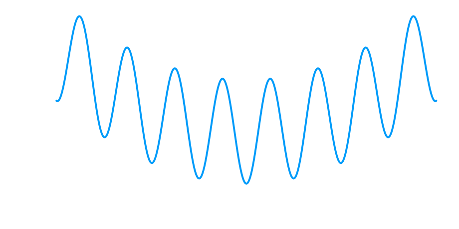

- Bereiche mit hoher Wirkung können von üblichen Algorithmen nicht gut überquert werden

**Hieran arbeite ich!**

## Was mache ich konkret?

**Entwicklung & Analyse von Simulationen**

[figure not shown]

**Veröffentlichung und Lesen von Artikeln**

[figure not shown]

**Lehre**

[figure not shown]

**Diskussion mit Physiker:innen weltweit auf Konferenzen oder Workshops**

[figure not shown]

## Warum Physik studieren?

- Lernen, komplexe Probleme zu lösen
- Sehr breite Berufsmöglichkeiten
- Neugier als Job 😄

## Take-Home Message

- Die Welt ist auf kleinster Skala extrem spannend
- Die allermeisten Rechungen sind nicht mehr analytisch möglich
- Lattice QCD verbindet Physik & Informatik (ohne langweiligen IT Kram)
- Vielleicht sitzt hier eine zukünftige Physikerin / ein zukünftiger Physiker 😉